# 연산자

## 연산(operation)과 연산자(operator)

프로그래밍 언어로 할 수 있는 대표적인 것인 바로 계산/연산이다.  
연산의 경우 컴퓨터가 사람보다 훨씬 빨리 잘할 수 있는 부분 중 하나로,하나 이상의 대상으로 새로운 것을 얻는 것을 의미한다.  
이러한 연산을 수행하기 위해 사용되는 기호 같은 것을 연산자라고 한다.

## 산술 연산자

이전 장에서 이미 사칙연산을 진행하기위해 산술 연산자를 사용하여 기본적인 계산을 진행하였다.  
사칙 연산자는 산술 연산자의 일부분이라고 할 수 있으며, 산술 연산자에는 사칙연산 외에도 몫, 나머지, 제곱 등이 있다.

### 사칙 연산자

- 파이썬에서 사용되는 기본적인 산술 연산자에 대해 배운다
- 더하기( + ), 빼기( - ), 곱하기( * ), 나누기( / )가 대표적이다.

[figure not shown]

### 사칙연산 진행

- 변수에 값을 넣어 기본적인 사칙 연산자를 사용 후 출력해본다.

※ 변수에 새로운 값을 넣으면 기존 값을 덮어쓰게 된다.파이썬에서 변수는 메모리 공간을 참조하는 이름에 불과하기에 변수에 새로운 값을 넣으면, 이전에 참조하고 있던 메모리 공간을 덮어쓰게되는 것이다. 이는 메모리를 효율적으로 사용하기 위한 방법 중 하나이다.

```python
n1 = 200
n2 = 150
```

```python
res = n1 + n2
print(res)
```

```
350
```

```python
res = n1 - n2
print(res)
```

```
50
```

```python
res = n1 * n2
print(res)
```

```
30000
```

```python
res = n1 / n2
print(res)
```

```
1.3333333333333333
```

### 산술 연산자의 우선순위

여러 개의 연산자가 동시에 계산에 나올 때가 있다.  
어떤 연산자가 먼저 계산되는지 정확히 파악해야 계산의 실수가 발생하지 않기 때문에 연산자의 계산 순서를 파악해야한다.

#### 더하기와 빼기의 경우

- 계산은 앞에서 뒤로(왼쪽에서 오른쪽 방향으로)진행된다.

```python
a, b, c = 3, 4, 5
print(a  +b  -c)
print(a  -c  +b)
print(-c +a  +b)
```

```
2
2
2
```

[figure not shown]

#### 나누기와 곱하기가 동시에 나오는 경우

- 계산은 앞에서 뒤로(왼쪽에서 오른쪽 방향으로)진행된다.

```python
a, b, c = 2, 4, 6
print(a / b * c)
print(a * c / b)
print(c / b * a)
```

```
3.0
3.0
3.0
```

[figure not shown]

#### 더하기(혹은 빼기)와 곱하기(혹은 나누기)가 동시에 나오는 경우

```python
a, b, c = 3, 4, 5

print(a * b + c)
print(c + a * b)
```

```
17
17
```

[figure not shown]

### 그 외의 연산자 ( 몫, 나머지, 제곱)

- 나눌 때 몫만 남기는 연산자 ( // )
- 나머지 값을 구하는 연산자( % )
- 제곱을 구하는 연산자 ( ** )

[figure not shown]

```python
q = 5 // 3
w = 5 % 3
r = 5 ** 3

print("나누기(몫): ", q)
print("나머지 값 : ", w)
print("제     곱 : ", r)
```

```
나누기(몫):  1
나머지 값 :  2
제     곱 :  125
```

## 입력된 숫자의 나머지와 몫을 계산하기

```python
num1 = int(input("나눠지는 수 ==> "))
num2 = int(input("나누는 수   ==> "))
q = num1 // num2 # 몫
r = num1 % num2 # 나머지
print(num1, '을(를)', num2, '(으)로 나눈 몫은 ', q, '입니다.')
print(num1, '을(를)', num2, '(으)로 나눈 나머지는 ', r, '입니다.')
```

```
나눠지는 수 ==> 25
나누는 수   ==> 10
25 을(를) 10 (으)로 나눈 몫은  2 입니다.
25 을(를) 10 (으)로 나눈 나머지는  5 입니다.
```

## 파운드(lb)와 킬로그램(kg)을 상호 변환하는 프로그램을 만들어 보자

- 00 헬스장은 미국에서 수입한 덤벨만 사용해 덤벨 무게가 킬로그램(kg)이 아닌 파운드(lb)로만 표시되어 있다.내가 드는 덤벨이 몇 킬로그램인지 알기 위해서 파운드-킬로그램 변환하는 프로그램을 만들어본다
- 각 15를 입력받았을 때, 파운드에서 킬로그램, 킬로그램에서 파운드로 무게의 단위를 변환해본다

[figure not shown]

#### 파운드 단위의 값을 입력받아 킬로그램으로 변환하기

```
파운드(lb)를 입력하세요 : 15
15 파운드(lb)는 6.8038799999999995 킬로그램(kb)입니다
```

#### 킬로그램 단위의 값을 입력받아 파운드로 변환하기

```
킬로그램(kg)을 입력하세요 : 15
15 킬로그램(kg)은 33.069345000000006  파운드(lb)입니다
```

**접기/펼치기**

#### 파운드에서 킬로그램 변환

pound = int(input("파운드(lb)를 입력하세요 : "))  
kg = pound * 0.453592  
print( pound, "파운드(lb)는", kg, "킬로그램(kb)입니다")

#### 킬로그램에서 파운드로 변환

kg = int(input("킬로그램(kg)을 입력하세요 : "))  
pound = kg * 2.204623  
print( kg, "킬로그램(kg)은", pound, " 파운드(lb)입니다")

## 대입 연산자

- 오른쪽의 값이나 계산 결과를 왼쪽으로 대입하라는 의미로, ‘ = ’ 연산자가 가장 기본적인 대입 연산자이다

#### 한개의 대입 연산자

- = 을 기준으로 오른쪽은 숫자, 수식, 문자열, 계산식 등 문법이 틀리지 않았다면 무엇이 와도 된다.

```python
num = 100
num = 100 * 200
num = int("100") + int("200")
print(num)
```

```
300
```

[figure not shown]

#### 여러 개의 대입연산자

- 콤마(,)로 분리해서 왼쪽에 변수가 2개 이상 나올 수도 있음
- 그런 경우에는 오른쪽도 반드시 콤마로 분리된 2개의 숫자, 수식, 문자열 등이 와야 함.
- 3개 이상도 한꺼번에 나올 수 있지만 ‘=‘을 기준으로 왼쪽과 오른쪽의 개수가 같아야 함

```python
num1, num2 = 100, 200

print(num1)
print(num2)
```

```
100
200
```

```python
num1, num2 = 100*200, 100+200

print(num1)
print(num2)
```

```
20000
300
```

```python
num1, num2 = int("100"), 100//5

print(num1)
print(num2)
```

```
100
20
```

[figure not shown]

#### 비정상적인 대입 방식

- = 을 기준으로 왼쪽과 오른쪽의 개수가 같아야 한다.
- 다르면, 변수와 값의 개수가 맞지 않아 에러가 발생한다.

```python
num1, num2, num3 = 100, 200
```

```
---------------------------------------------------------------------------
ValueError                                Traceback (most recent call last)
Input In [8], in <cell line: 1>()
----> 1 num1, num2, num3 = 100, 200

ValueError: not enough values to unpack (expected 3, got 2)
```

```python
num1, num2 = 100
```

```
---------------------------------------------------------------------------
TypeError                                 Traceback (most recent call last)
Input In [9], in <cell line: 1>()
----> 1 num1, num2 = 100

TypeError: cannot unpack non-iterable int object
```

```python
num1 = 100, 200 # 이 경우에는 에러가 발생하지는 않는다. 7장에서 설명
```

## 대입 연산자의 활용

- 변수에 값을 변경한 후 다시 자신에게 대입하는 복합 연산자의 역할을 살펴본다.
- 복합연산자는 코드를 간결하게 만들 수 있으며, 반복적으로 같은 변수에 대해 연산을 수행할 때 유용하다.

#### 대입 연산자의 활용

- 변수에 값을 변경한 후에 다시 자신에게 대입할 수 있다.

```python
num1 = 100

num1 = num1 + 200  # num1 += 200

print(num1)
```

```
300
```

[figure not shown]

- 위 코드를 줄여서 아래와 같이 표현 가능하다.
- num1 = num1 + 200 과 num1 += 200 는 같은 표현이다

```python
num1 = 100
num1 += 200 # num1 = num1 + 200
print(num1)
```

```
300
```

#### 복합 대입 연산자는 아래와 같이 존재한다.

[figure not shown]

- 복합 연산자의 간단한 사용 실습

```python
num = 20
num += 3 # 더하기
print(num)
num -= 3 # 빼기
print(num)
num *= 3 # 곱하기
print(num)
num /= 3 # 나누기
print(num)
num //= 3 # 몫
print(num)
num %= 3 # 나머지
print(num)
num **= 3  # 제곱
print(num)
```

```
23
20
60
20.0
6.0
0.0
0.0
```

- 줄이 바뀌면 자동으로 해당 구문이 종료되었음을 인식 하여 끝난다.
- 세미콜론(;)을 사용하면 줄을 바꾼 효과를 내어 한 줄에 여러 명령을 쓸 수 있다.
- 다른언어에선 구문이 끝날때마다 세미콜론을 붙여주지만, 파이썬은 꼭 붙여줄 필요는 없기 때문에 필수는 아니다.

```python
num = 20
num += 3 ; print(num)
num -= 3 ; print(num) # 빼기
num *= 3 ; print(num) # 곱하기
num /= 3 ; print(num) # 나누기
num //= 3 ; print(num) # 몫
num %= 3 ; print(num) # 나머지
num **= 3 ; print(num) # 제곱
```

```
23
20
60
20.0
6.0
0.0
0.0
```

## 편의점 하루 매출 계산하기

- 편의점은 본사에서 물품값을 지불 후 구입하여 일정 금액을 붙여 손님에게 판매한다.
- 편의점에서 하루동안 구입 또는 판매한 물건의 총 매출을 계산하는 프로그램을 만들어보자

[figure not shown]

**접기/펼치기**

#### # 변수를 0으로 초기화

total = 0

#### # 총 매출액 출력

print("오늘 총 매출액은 ", total, "원입니다")

```python
# 변수를 0으로 초기화
total = 0

# 구입 물품은 구입가격에 개수를 곱한 후 총 매출액에서 제외
total = total - 900 * 10
total = total - 3500 * 5

# 판매 물품은 판매 가격에 개수를 곱한 후 총 매출액에서 제외
total += 1800 * 2
total += 4000 * 4
total += 1500
total += 2000 * 4
total += 1800 * 5

# 총 매출액 출력
print("오늘 총 매출액은 ", total, "원입니다")
```

```
오늘 총 매출액은  11600 원입니다
```

# 구매 금액의 10%가 적립되는 프로그램

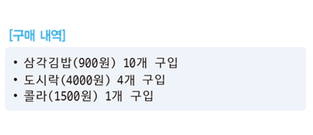

```
구입금액:  26500 원
적립금액:  2650.0 원
```

**접기/펼치기**

total = 0

point = total *0.1  
print("적립금액: ", point, "원")

## 비교 연산자와 논리 연산자

### 비교 연산자란?!

- 어떤 것이 큰지, 작은지, 혹은 같은지를 비교하는 연산자
- 결과는 참을 의미하는 True와 거짓을 의미하는 False로 표시함
- 비교 연산자를 단독으로 사용하는 경우는 거의 없음
- 조건문이나 반복문과 함께 사용함

[figure not shown]

- 100<200 의 경우 100보다 200이 크기 떄문에 결과는 참을 의미하는 True
- 100>200 의 경우 100이 200보다 크지 않기 때문에 거짓을 의미하는 False  
  ※ 앞에 나온 숫자를 기준으로 이야기해서 200이 100보다 크다 라고 하지는 않음

### 비교 연산자의 활용

- 변수에 들어 있는 값을 주로 사용함

[figure not shown]

#### 운전면허 필기 시험 점수

- 운전면허 필기 시험 점수를 입력받아서 70점 이상이면 합격(True), 그렇지 않으면 불합격(False)로 처리한다고 하자.
- 이 내용을 코드로 작성해보자

```python
score = int(input("시험점수를 입력하세요 ==>"))
print(score >= 70)
```

```
시험점수를 입력하세요 ==>100
True
```

```python
score = int(input("시험점수를 입력하세요 ==>"))
print(score >= 70)
```

```
시험점수를 입력하세요 ==>50
False
```

### 비교 연산자의 종류

- 파이썬에서 사용할 수 있는 비교연산자의 종류

[figure not shown]

#### 비교 연산자(==)와 대입연산자(=)

- == 의 경우 비교하려는 두 값이 동일할 경우 참(True)값을 주도록 하는 비교 연산자
- 대입 연산자 = 과 헷갈려 하나만 사용하게 되면 오른쪽 값을 왼쪽에 대입하라는 의미가 되기 때문에 오류가 생긴다

```python
n1,n2 = 100, 200
print( n1 == n2 )
```

```
False
```

```python
n1,n2 = 100,200
print( n1 = n2 )
```

```
---------------------------------------------------------------------------
TypeError                                 Traceback (most recent call last)
Input In [3], in <cell line: 2>()
      1 n1,n2 = 100,200
----> 2 print( n1 = n2)

TypeError: 'n1' is an invalid keyword argument for print()
```

비교연산자를 연속적으로 사용하여 출력해도 오류가 발생하지는 않음.  
print() 안에 쉼표(,)로 구분하여 여러 개의 값을 출력하면 각 연산은 독립적으로 계산되어 출력된다.  
따라서 같이 여러 번 사용해도 문제가 되지 않는다.

```python
n1, n2 = 100, 200
print(n1>n2 , n1<n2 , n1!=n2 , n1==n2 )
```

```
False True True False
```

### 비교 연산자의 예제

```python
n1 = 100 ; n2 = 200

print("n1과 n2가 같은가? ", n1 == n2)
```

```
n1과 n2가 같은가?  False
```

```python
n1 = 100 ; n2 = 200

print("n1과 n2가 같지않은가? ", n1 != n2)
```

```
n1과 n2가 같지않은가?  True
```

### 비교연산자를 사용하여 아래의 출력이 나오도록 코드 작성하기

- print()함수를 사용해서 6개의 비교연산자를 사용해 출력해본다.
- ==, != , > , < , >= , >=

**접기/ 펼치기**

- n1 = 100 ; n2 = 200 - print("n1과 n2가 같은가요? ", n1 == n2) - print("n1과 n2가 같지 않은가요? ", n1 != n2) - print("n1가 n2보다 큰가요? ", n1 > n2) - print("n2가 n1보다 큰가요? ", n1 < n2) - print("n1가 n2보다 크거나 같나요?", n1 >= n2) - print("n2가 n1보다 크거나 같나요?",n1 <= n1)

```
n1과 n2가 같은가요?  False
n1과 n2가 같지 않은가요?  True
n1가 n2보다 큰가요?  False
n2가 n1보다 큰가요?  True
n1가 n2보다 크거나 같나요? False
n2가 n1보다 크거나 같나요? True
```

### 논리 연산자란?

- 비교 연산자가 여러 번 필요할 때 사용함.
- 종류는 크게 세 가지(and(그리고), or(또는), not(부정))이 존재함.
- 만약 num 변수의 값이 10과 20 사이에 있어야 한다면 두개의 조건이 필요하다.

조건1) num은 10보다 커야 함.  
조건2) num은 20보다 작아야 함.

[figure not shown]

- 이 때 num이 10과 20사이에 있으려면 두개의 조건을 모두 만족하는 'and(그리고)' 라는 연산자가 필요하다
- 계산되는 차례는 아래와 같다.
  - ① num>10이 True인지 False인지 확인한다.
  - ② num<20이 True인지 False인지 확인한다.
  - ③ ①과 ②의 결과를 and로 처리한다.
  - and는 둘 다 True일 때 True가 된다. 둘 중 하나라도 False인 결과가 있다면 최종 결과도 False가 된다.

```python
num = 15
(num>10) and ( num < 20)
```

```
True
```

```python
num = 25
(num>10) and ( num < 20)
```

```
False
```

### 논리 연산자의 종류

[figure not shown]

### 논리 연산자 예시

- num의 값이 99일 때,

```python
num = 99
```

```python
(num > 100) and (num < 200)
```

```
False
```

```python
(num == 99) or (num == 100)
```

```
True
```

```python
not(num == 100)
```

```
True
```

## 숫자를 입력받았을 때, 값이 홀수면 True, 값이 짝수면 False가 나오는 프로그램을 만들어보자

**접기/펼치기**

num1 = int(input("숫자를 입력하세요: "))  
num2 = (num1 % 2)  
result = (num2 ==1) # 혹은 (num2 !=0)  
print("결과:", result)

```python
num1 = int(input("숫자를 입력하세요: "))
num2 = num1 % 2
result = num2 ==1
print("결과:", result)
```

```
숫자를 입력하세요: 3
결과: True
```

#### ※ if문의 사용

```python
num1 = int(input("숫자를 입력하세요: "))
num2 = (num1 % 2) # 나머지 값을 구한다
result = (num2 == 1) # 혹은 (num2 !=0),
                     #  2로 나머지를 구하면 결과는 0 아니면 1이 나오게 됨
                     # 나머지 값이 1인가? ture,
                     # 1이 아니라면 false
if result:
    print("홀수 입니다!")
else:
    print("짝수 입니다!")
```

```
숫자를 입력하세요: 10
짝수 입니다!
```

## 연산자의 우선순위

- 연산자가 동시에 나올 경우 어떤 연산자를 먼저 계산할지 결정되어 있는 순서
- 파이썬은 연산자의 종류가 상당히 많음
- 아직 배우지 않은 연산자도 존재하기 때문에 가볍게 살펴본다.
- 괄호가 가장 우선순위가 가장 높고, 대입연산자는 나중에 처리된다는 점 정도만 기억

[figure not shown]

### 괄호 ( ) 를 사용하면 우선 연산 되는 것을 확인할 수 있음

```python
a, b, c = 2, 4, 6

print("a + b * c   = ", a + b * c)
print("(a + b) * c = ", (a + b) * c) # 괄호 사용
print("")
print("a / b + c   = ", a / b + c)
print("a / (b + c) = ", a / (b + c))  # 괄호 사용
```

```
a + b * c   =  26
(a + b) * c =  36

a / b + c   =  6.5
a / (b + c) =  0.2
```

### 주석

- 주석이 있으면 코드가 실행되지 않기 때문에 코드에 설명을 달 때 사용한다.
- 혹은 코드의 일부분을 비활성화 하고 싶을 때 사용한다.  
  #### 한 줄 주석
  - ' # ' 은 한 줄 주석을 의미하는데 ' # ' 이후부터 작성되는 문장(코드)은 실행되지 않아 코드 실행결과에 영향을 미치지 않는다.

  #### 여러 줄 주석
  - 한 줄 이상의 여러줄을 한번에 주석 처리 하고 싶을 경우, 주석 처리하고 싶은 문장(코드)의 시작과 끝에 큰 따옴표(""") 또는 작은 따옴표(''')를 연속으로 3개 사용한다.

## 기말 평균 학점 구하기

- 아래의 성적표를 참고하여 평균 학점을 구해보자
- 성적은 과목의 이수학점에 영향을 받는다.
- 각 과목의 이수학점과 해당하는 성적을 곱한 뒤, 총 이수 학점의 합(6)으로 나누어 평균 학점을 구한다.

[figure not shown]

**접기/펼치기**

#### # 각 과목에 대응하는 이수학점

python = 3  
mobile = 2  
excel = 1

#### # 수업별 성적

A = 4.5  
A0 = 4.0  
B = 3.5

#### # 최종 학점 계산

avg = ((python *B) + (mobile* A0) + (excel * A)) / (python + mobile + excel)

#### # 결과

print("평균 학점:", avg) #round(avg,2)

[output not shown]

# 요약

1. 파이썬에서 주로 사용하는 산술 연산자는 더하기( + ), 뺴기( - ), 곱하기( * ), 나누기( / ), 몫( // ), 나머지( % ), 제곱( ** )이 대표적이다.
2. 여러 개의 연산자가 동시에 계산에 나올 때는 어떤 연산자가 먼저 계산되는지 정확히 파악해야 계산의 실수가 없다.
3. 대입 연산자란 오른쪽의 값이나 계산 결과를 왼쪽으로 대입하라는 의미로, ' = '연산자가 가장 기본적인 대입 연산자이다.
4. 비교 연산자는 어떤 것이 큰지, 작은지, 같은지를 비교하는 것으로, 그 결과는 참(True)이거나 거짓(False)이 된다. 비교 연산자를 단독으로 사용하는 경우는 거의 없으며, 조건문이나 반복문과 함께 사용한다.
5. 논리 연산자는 비교 연산자가 여러 번 필요할 때 사용한다. 종류로는 and(그리고), or(또는), not(부정) 세 가지가 있다.
6. 파이썬에는 연산자의 종류가 상당히 많이 있다. 한 줄에 여러 연산자가 동시에 나올 경우 어떤 연산자를 먼저 계산할지 이미 결정되어 있는데, 이런 순서를 연산자 우선순위라고 한다.